# Ch1: Golem of Prague

Jesse Brunner

## Statistical models as golems

- Powerful & unyielding
- Follow instructions with single-minded purpose
- Only “know” what they are told to do

Cannot tell us what is “right” or “True”

Cannot even tell us what is “OK to say” (*not* police!)

Golems are *tools*

## Why can’t golems *rule out* or *falsify* hypotheses?

1. Hypotheses are not models<sup>1</sup>
- One hypothesis might be represented by many model**s**

*Hypothesis*: pathogen transmission is shaped by variability in susceptibility

*Models*: $\beta I^p S^q$, $ks \ln\left(1+\frac{\beta I}{k}\right)$, $\frac{\beta S I}{c+S+I}$, …

[^1]: golems only know how to deal with models

## Why can’t golems *rule out* or *falsify* hypotheses?

1. Hypotheses are not models
- One hypothesis might be represented by many model**s**
- One model might be consistent with many hypothese**s**

*All* of those models might come from heterogeneity in susceptibility…

but also come from spatial or contact structure, etc.

## Why can’t golems *rule out* or *falsify* hypotheses?

1. Hypotheses are not models
2. Measurements matter
- Observation error: *uncertainty in what we observe, biases, measurement error*
- Hypotheses are continuous: *X is more/less important, not simply T/F*

How close is close/far enough?  
Any threshold or decision rule is arbitrary

## Let’s simulate some data

| Round | Heads | Coins flipped |
| --- | --- | --- |
| 1 |  |  |
| 2 |  |  |
| 3 |  |  |
| 4 |  |  |
| 5 |  |  |
| 6 |  |  |
| 7 |  |  |
| 8 |  |  |
| 9 |  |  |
| 10 |  |  |
| 11 |  |  |
| 12 |  |  |
| 13 |  |  |
| 14 |  |  |
| 15 |  |  |
| 16 |  |  |
| 17 |  |  |
| 18 |  |  |
| 19 |  |  |
| 20 |  |  |

## Why can’t golems *rule out* or *falsify* hypotheses?

1. Hypotheses are not models
2. Measurements matter
3. We make inference as a group, by consensus, outside of routines

Science is not a series of statistical procedures!

**We must be the captains of our own ships**

## What do you want from your statistics?

Understand **causation**?

- Does $x \rightarrow y$?
- Is $x_1$ more important than $x_2$?
- What is the value of parameter $\beta$?

**Predict** likely outcomes?

- Which model is better at predicting new observations?
- What can we expect in a new time or place?

*These are not the same*

## Different goals require different approaches

Understand **causation**?

- Experiments
- Directed acyclic graphs
- Path analysis

**Predict** future outcomes?

- Cross validation
- Information criteria
- Sensitivity analysis

Good prediction $\neq$ causation

## You are the captain of your own ship

You must learn to

- think carefully and skeptically (theory, DAGs, etc.)
- be specific about what you want to know (estimands)
- see the consequences of the assumptions you are making (simulations)
- understand and embrace uncertainty (distributions)
- dive into the weeds! (this class)

Analysis is not an easy afterthought after the hard work of collecting the data… It is a core part of the whole process!

## Simulation is a super power

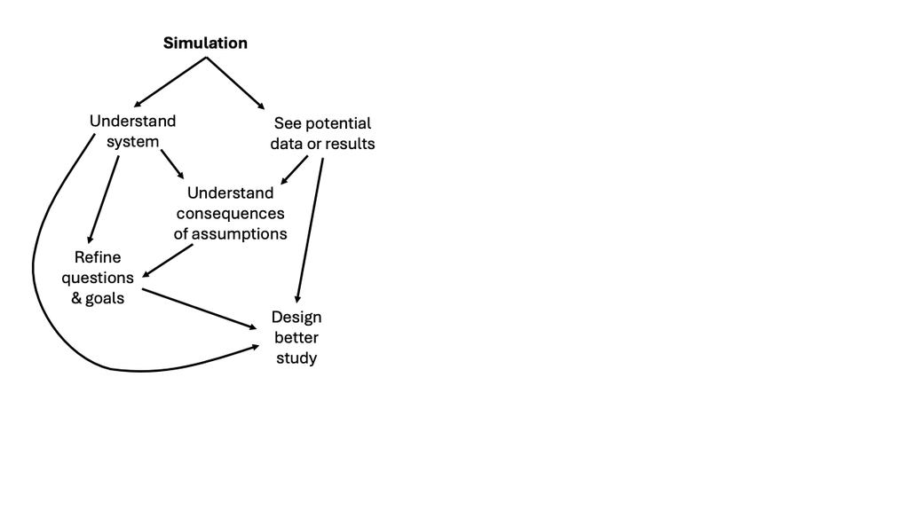

## Simulation is a super power

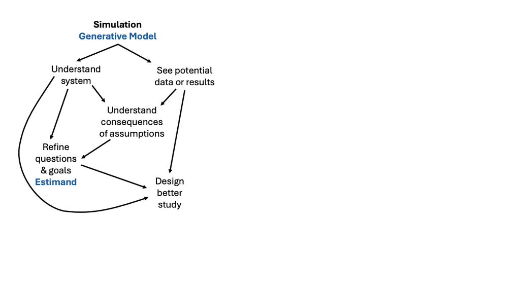

## Simulation is a super power

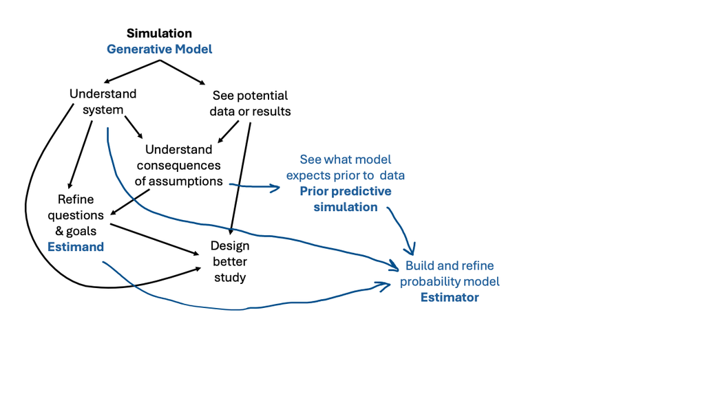

## Simulation is a super power

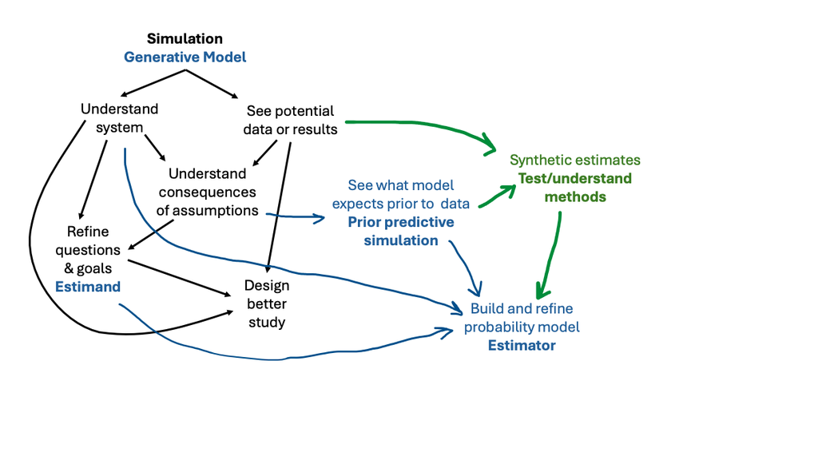

## Simulation is a super power

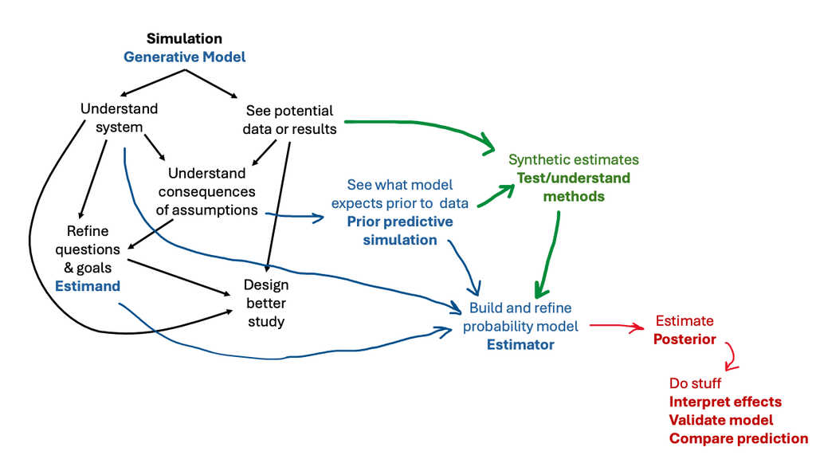